# Data Exploration

## Tools Used in Data Exploration

In this section, we will focus on exploring the data and understanding the data. For each dataset, we will try to find interesting trait or correlation between them or across dataset in order to answer the questions we proposed and refine our hypothesis. We will use the following tools to help us in this process: Pandas and Seaborn.

### Dataset for popular songs

```python
import pandas as pd
import numpy as np
import matplotlib.pyplot as plt
import seaborn as sns
```

```python
# load the data
df_spotify_track = pd.read_csv('../data/01-modified-data/spotify_current_all.csv')
```

```python
print(df_spotify_track.head())
```

```
   danceability  energy  key  loudness  mode  speechiness  acousticness  \
0         0.864   0.556    2    -7.683     0       0.1940         0.255
1         0.802   0.832   11    -4.107     1       0.0434         0.311
2         0.552   0.702    9    -5.707     1       0.1570         0.117
3         0.841   0.738    7    -7.455     0       0.3070         0.520
4         0.628   0.523   11    -8.307     0       0.0946         0.701

   instrumentalness  liveness  valence    tempo                track_id  \
0          0.000004    0.1120    0.726   99.974  56y1jOTK0XSvJzVv9vHQBK
1          0.000000    0.0815    0.890  124.997  7x9aauaA9cu6tyfpHnqDLo
2          0.000021    0.1050    0.564  169.994  1BxfuPKGuaTgP7aM0Bbdwr
3          0.000000    0.0892    0.484  169.918  5RqSsdzTNPX1uzkmlHCFvK
4          0.002740    0.2190    0.416  169.982  5mjYQaktjmjcMKcUIcqz4s

               artist_ids                           track_name          name  \
0  5cj0lLjcoR7YOSnhnX0Po5                   Paint The Town Red      Doja Cat
1  6HaGTQPmzraVmaVxvz6EUc  Seven (feat. Latto) (Explicit Ver.)     Jung Kook
2  06HL4z0CvFAxyc27GXpf02                         Cruel Summer  Taylor Swift
3  790FomKkXshlbRYZFtlgla                                QLONA       KAROL G
4  7uMDnSZyUYNBPLhPMNuaM2                            Strangers   Kenya Grace

  broad_genre
0         pop
1         pop
2         pop
3       latin
4      others
```

Here is a statisiical summary of the dataset for popular songs.

```python
print(df_spotify_track.describe())
```

```
       danceability      energy         key    loudness        mode  \
count    187.000000  187.000000  187.000000  187.000000  187.000000
mean       0.652583    0.640706    5.085561   -6.201134    0.647059
std        0.145082    0.164622    3.582087    2.139002    0.479168
min        0.351000    0.091100    0.000000  -17.665000    0.000000
25%        0.541000    0.535500    1.000000   -7.515000    0.000000
50%        0.647000    0.669000    5.000000   -5.745000    1.000000
75%        0.767000    0.762500    8.000000   -4.635500    1.000000
max        0.971000    0.989000   11.000000   -2.278000    1.000000

       speechiness  acousticness  instrumentalness    liveness     valence  \
count   187.000000    187.000000        187.000000  187.000000  187.000000
mean      0.085687      0.242592          0.014381    0.168414    0.507722
std       0.083841      0.247013          0.076317    0.122816    0.244540
min       0.025400      0.000390          0.000000    0.029700    0.034800
25%       0.036750      0.048200          0.000000    0.097050    0.318500
50%       0.053800      0.145000          0.000000    0.120000    0.488000
75%       0.088300      0.405000          0.000027    0.186000    0.696500
max       0.397000      0.959000          0.629000    0.923000    0.964000

            tempo
count  187.000000
mean   122.745358
std     29.703599
min     66.041000
25%     98.516500
50%    122.811000
75%    143.019500
max    203.759000
```

#### What is the dominate genre in the current top songs?

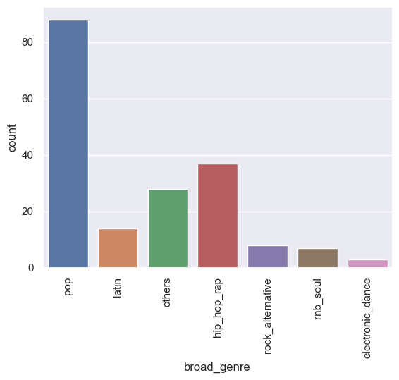

```python
sns.countplot(x='broad_genre', data=df_spotify_track)
plt.xticks(rotation=90)

plt.show()
```

From this plot, it’s evident that pop music dominates the current top songs, followed by hip hop as the second most popular genre. Notably, the third most prevalent category is ‘others,’ which comprises songs that don’t fit neatly into established genres. This might hint at the growing trend of genreless music. However, a comparison with older songs is necessary to determine if this is a recent phenomenon.

### The genre’s in popular songs’s changing over time

```python
# load the data
df_spotify_history = pd.read_csv('../data/01-modified-data/top50MusicFrom2010-2019_cleaned.csv')
```

```python
df_spotify_history.head()
```

|  | title | artist | genre | year | beat | energy | danceability | loudness | valence | duration | acousticness | speechiness | popularity | year_group |
| --- | --- | --- | --- | --- | --- | --- | --- | --- | --- | --- | --- | --- | --- | --- |
| 0 | Hey, Soul Sister | Train | pop | 2010 | 97 | 89 | 67 | -4 | 80 | 217 | 19 | 4 | 83 | 2010-2014 |
| 1 | Love The Way You Lie | Eminem | hip_hop_rap | 2010 | 87 | 93 | 75 | -5 | 64 | 263 | 24 | 23 | 82 | 2010-2014 |
| 2 | TiK ToK | Kesha | pop | 2010 | 120 | 84 | 76 | -3 | 71 | 200 | 10 | 14 | 80 | 2010-2014 |
| 3 | Bad Romance | Lady Gaga | pop | 2010 | 119 | 92 | 70 | -4 | 71 | 295 | 0 | 4 | 79 | 2010-2014 |
| 4 | Just the Way You Are | Bruno Mars | pop | 2010 | 109 | 84 | 64 | -5 | 43 | 221 | 2 | 4 | 78 | 2010-2014 |

Statistics summary

```python
df_spotify_history.describe()
```

|  | year | beat | energy | danceability | loudness | valence | duration | acousticness | speechiness | popularity |
| --- | --- | --- | --- | --- | --- | --- | --- | --- | --- | --- |
| count | 603.000000 | 603.000000 | 603.000000 | 603.000000 | 603.000000 | 603.000000 | 603.000000 | 603.000000 | 603.000000 | 603.000000 |
| mean | 2014.592040 | 118.545605 | 70.504146 | 64.379768 | -5.578773 | 52.225539 | 224.674959 | 14.326700 | 8.358209 | 66.520730 |
| std | 2.607057 | 24.795358 | 16.310664 | 13.378718 | 2.798020 | 22.513020 | 34.130059 | 20.766165 | 7.483162 | 14.517746 |
| min | 2010.000000 | 0.000000 | 0.000000 | 0.000000 | -60.000000 | 0.000000 | 134.000000 | 0.000000 | 0.000000 | 0.000000 |
| 25% | 2013.000000 | 100.000000 | 61.000000 | 57.000000 | -6.000000 | 35.000000 | 202.000000 | 2.000000 | 4.000000 | 60.000000 |
| 50% | 2015.000000 | 120.000000 | 74.000000 | 66.000000 | -5.000000 | 52.000000 | 221.000000 | 6.000000 | 5.000000 | 69.000000 |
| 75% | 2017.000000 | 129.000000 | 82.000000 | 73.000000 | -4.000000 | 69.000000 | 239.500000 | 17.000000 | 9.000000 | 76.000000 |
| max | 2019.000000 | 206.000000 | 98.000000 | 97.000000 | -2.000000 | 98.000000 | 424.000000 | 99.000000 | 48.000000 | 99.000000 |

We can observe from the basic statistic that most of the statistic are quite similar to the ones in the currently hot songs.

```python
df_spotify_history.columns
```

```
Index(['title', 'artist', 'genre', 'year', 'beat', 'energy', 'danceability',
       'loudness', 'valence', 'duration', 'acousticness', 'speechiness',
       'popularity', 'year_group'],
      dtype='object')
```

```python
df_histroy_melted  = df_spotify_history.melt(id_vars=['title', 'artist', 'year', 'beat', 'energy', 'danceability',
       'loudness', 'valence', 'duration', 'acousticness', 'speechiness',
       'popularity', 'year_group'], var_name='feature', value_name='value')
```

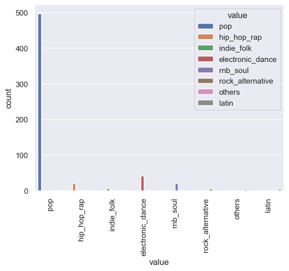

```python
sns.countplot(x='value', data=df_histroy_melted, hue='value')
plt.xticks(rotation=90)

plt.show()
```

From this plot, it’s evident that the past decade witnessed an overwhelming dominance of pop music, comprising nearly all of the top songs. Electronic dance music emerged as the second most successful genre, with hip hop not even ranking third in popularity. There appears to have been some significant shifts in musical trends over the past decade. To highlight these changes more clearly, we should create another graph comparing the genre proportions from the last decade with those in the current top songs.

```python
# construst the dataset
df1 = df_spotify_history['genre'].value_counts() / df_spotify_history['genre'].value_counts().sum()

df2 = df_spotify_track['broad_genre'].value_counts() / df_spotify_track['broad_genre'].value_counts().sum()
```

```python
df1 = pd.DataFrame(df1)
# df1.set_index('genre').T
```

```python
df1
df1.reset_index(inplace=True)
df1['type'] = 'history'
```

```python
df2 = pd.DataFrame(df2)
df2.reset_index(inplace=True)
df2['type'] = 'current'
df2.rename(columns={'broad_genre':'genre'}, inplace=True)
```

```python
df_genre_compare = pd.concat([df1, df2], axis=0)
```

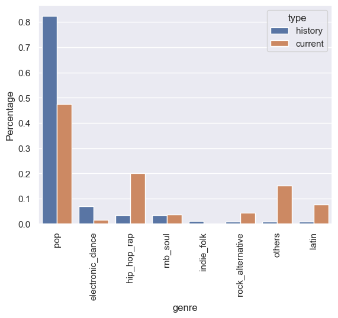

```python
sns.barplot(x='genre', y='count', data=df_genre_compare, hue='type')
plt.xticks(rotation=90)
plt.ylabel('Percentage')
plt.show()
```

This plot contrasts the proportion of each genre in the current top songs with those from the past decade. Notably, pop music’s share has seen a substantial decline, while other genres, particularly hip hop (now the second most prevalent genre in current top songs), have witnessed a surge. A significant observation is the minimal percentage of the ‘others’ category in past top songs, which now claims a notable share. This might be attributed to the emergence of hybrid genres like ‘gauze pop’ and ‘escape room’ that don’t fit conventional classifications and have only gained recognition recently. Latin music has also experienced a resurgence. In summary, there’s been a shift in genre distribution over the years, but a more detailed time-based analysis is needed to capture the full evolution.

```python
df_genre_change = df_spotify_history.copy()
df_genre_change['count'] = 0
for i in range(len(df_genre_change)):
    df_genre_change['count'][i] = len(df_genre_change[df_genre_change['year'] == df_genre_change['year'][i]])
```

```python
df_genre_change['propotion'] = 1 / df_genre_change['count']
```

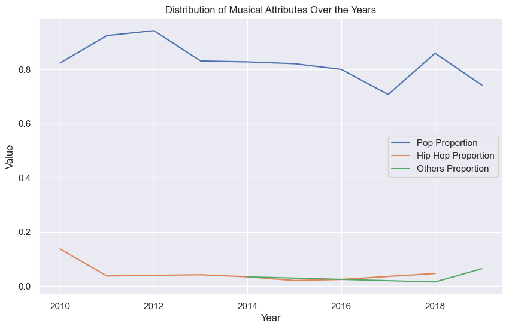

```python
sns.set_theme()

# Create line plots for each genre or attribute
plt.figure(figsize=(10, 6))
sns.lineplot(data=df_genre_change[df_genre_change['genre'] == 'pop'], x='year', y='propotion', label='Pop Proportion', estimator='sum')
sns.lineplot(data=df_genre_change[df_genre_change['genre'] == 'hip_hop_rap'], x='year', y='propotion', label='Hip Hop Proportion', estimator='sum')
sns.lineplot(data=df_genre_change[df_genre_change['genre'] == 'others'], x='year', y='propotion', label='Others Proportion', estimator='sum')
# ... Add other attributes as needed

# sns.lineplot(data=df_spotify_history, x='year', y='energy', label='Energy')

# Add title, labels, and legend
plt.title('Distribution of Musical Attributes Over the Years')
plt.xlabel('Year')
plt.ylabel('Value')
plt.legend()

# Show the plot
plt.show()
```

In the presented plot, we observe that the proportion of pop music within top songs each year doesn’t show a consistent decline but fluctuates over time. Nonetheless, the overarching trend suggests a decrease in the popularity of pop music. Hip hop music experienced a marked drop starting in 2010, stabilizing for several years thereafter. From 2015 onwards, hip hop’s proportion began to rise again. Furthermore, the “others” category, representing emerging genres not easily classified into traditional categories, began to see an uptick starting in 2018.

### Has the popular song more homogenized over time?

To do so, we will need to see the distribution of multipy musical features in the top songs over time.

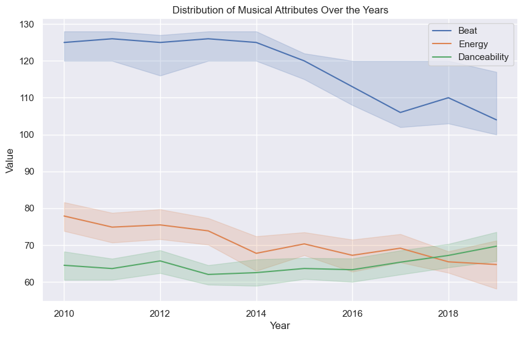

```python
sns.set_theme()

# Create line plots for each genre or attribute
plt.figure(figsize=(10, 6))
sns.lineplot(data=df_spotify_history, x='year', y='beat', label='Beat', estimator='median')
sns.lineplot(data=df_spotify_history, x='year', y='energy', label='Energy')
sns.lineplot(data=df_spotify_history, x='year', y='danceability', label='Danceability')
# ... Add other attributes as needed

# sns.lineplot(data=df_spotify_history, x='year', y='energy', label='Energy')

# Add title, labels, and legend
plt.title('Distribution of Musical Attributes Over the Years')
plt.xlabel('Year')
plt.ylabel('Value')
plt.legend()

# Show the plot
plt.show()
```

### Tik Tok Dataset and Related Analysis

```python
# load the data
df_tik_tok = pd.read_csv('../data/01-modified-data/tik_tok_cleaned.csv')
```

```python
df_tik_tok.head()
```

|  | track_name | artist | track_pop | danceability | energy | loudness | mode | key | speechiness | acousticness | instrumentalness | liveness | valence | tempo | time_signature | duration_ms |
| --- | --- | --- | --- | --- | --- | --- | --- | --- | --- | --- | --- | --- | --- | --- | --- | --- |
| 0 | Running Up That Hill (A Deal With God) | Kate Bush | 95 | 0.629 | 0.547 | -13.123 | 0 | 10 | 0.0550 | 0.7200 | 0.003140 | 0.0604 | 0.197 | 108.375 | 4 | 298933 |
| 1 | As It Was | Harry Styles | 96 | 0.520 | 0.731 | -5.338 | 0 | 6 | 0.0557 | 0.3420 | 0.001010 | 0.3110 | 0.662 | 173.930 | 4 | 167303 |
| 2 | Sunroof | Nicky Youre | 44 | 0.768 | 0.716 | -5.110 | 1 | 10 | 0.0404 | 0.3500 | 0.000000 | 0.1500 | 0.841 | 131.430 | 4 | 163026 |
| 3 | Heat Waves | Glass Animals | 89 | 0.761 | 0.525 | -6.900 | 1 | 11 | 0.0944 | 0.4400 | 0.000007 | 0.0921 | 0.531 | 80.870 | 4 | 238805 |
| 4 | About Damn Time | Lizzo | 92 | 0.836 | 0.743 | -6.305 | 0 | 10 | 0.0656 | 0.0995 | 0.000000 | 0.3350 | 0.722 | 108.966 | 4 | 191822 |

Statistics summary

```python
df_tik_tok.describe
```

```
<bound method NDFrame.describe of                                  track_name           artist  track_pop  \
0    Running Up That Hill (A Deal With God)        Kate Bush         95
1                                 As It Was     Harry Styles         96
2                                   Sunroof      Nicky Youre         44
3                                Heat Waves    Glass Animals         89
4                           About Damn Time            Lizzo         92
..                                      ...              ...        ...
258              The Less I Know The Better      Tame Impala         84
259                              Dandelions          Ruth B.         90
260           Jimmy Cooks (feat. 21 Savage)            Drake         92
261                            Good Looking  Suki Waterhouse         80
262                                 INFERNO        Sub Urban         71

     danceability  energy  loudness  mode  key  speechiness  acousticness  \
0           0.629   0.547   -13.123     0   10       0.0550      0.720000
```

[output cut: 25 more lines]

```python
df_spotify_history.columns
```

```
Index(['title', 'artist', 'genre', 'year', 'beat', 'energy', 'danceability',
       'loudness', 'valence', 'duration', 'acousticness', 'speechiness',
       'popularity', 'year_group'],
      dtype='object')
```

```python
# construst the dataset
df1 = df_spotify_track.copy()
df1['type'] = 'spotify'
df1.rename(columns={'broad_genre':'genre'}, inplace=True)
df2 = df_tik_tok.copy()
df2['type'] = 'tik_tok'

df_tik_spotify = pd.concat([df1, df2], axis=0)
```

```python
df_tik_spotify.head()
```

|  | danceability | energy | key | loudness | mode | speechiness | acousticness | instrumentalness | liveness | valence | ... | track_id | artist_ids | track_name | name | genre | type | artist | track_pop | time_signature | duration_ms |
| --- | --- | --- | --- | --- | --- | --- | --- | --- | --- | --- | --- | --- | --- | --- | --- | --- | --- | --- | --- | --- | --- |
| 0 | 0.864 | 0.556 | 2 | -7.683 | 0 | 0.1940 | 0.255 | 0.000004 | 0.1120 | 0.726 | ... | 56y1jOTK0XSvJzVv9vHQBK | 5cj0lLjcoR7YOSnhnX0Po5 | Paint The Town Red | Doja Cat | pop | spotify | NaN | NaN | NaN | NaN |
| 1 | 0.802 | 0.832 | 11 | -4.107 | 1 | 0.0434 | 0.311 | 0.000000 | 0.0815 | 0.890 | ... | 7x9aauaA9cu6tyfpHnqDLo | 6HaGTQPmzraVmaVxvz6EUc | Seven (feat. Latto) (Explicit Ver.) | Jung Kook | pop | spotify | NaN | NaN | NaN | NaN |
| 2 | 0.552 | 0.702 | 9 | -5.707 | 1 | 0.1570 | 0.117 | 0.000021 | 0.1050 | 0.564 | ... | 1BxfuPKGuaTgP7aM0Bbdwr | 06HL4z0CvFAxyc27GXpf02 | Cruel Summer | Taylor Swift | pop | spotify | NaN | NaN | NaN | NaN |
| 3 | 0.841 | 0.738 | 7 | -7.455 | 0 | 0.3070 | 0.520 | 0.000000 | 0.0892 | 0.484 | ... | 5RqSsdzTNPX1uzkmlHCFvK | 790FomKkXshlbRYZFtlgla | QLONA | KAROL G | latin | spotify | NaN | NaN | NaN | NaN |
| 4 | 0.628 | 0.523 | 11 | -8.307 | 0 | 0.0946 | 0.701 | 0.002740 | 0.2190 | 0.416 | ... | 5mjYQaktjmjcMKcUIcqz4s | 7uMDnSZyUYNBPLhPMNuaM2 | Strangers | Kenya Grace | others | spotify | NaN | NaN | NaN | NaN |

5 rows × 21 columns

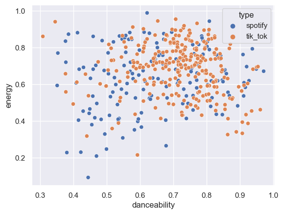

```python
sns.scatterplot(data=df_tik_spotify, x='danceability', y='energy', hue='type')
```

### What are the features relative to the popularity of the songs?

```python
# Load the data
df_tracks = pd.read_csv('../data/00-raw-data/tracks.csv')
```

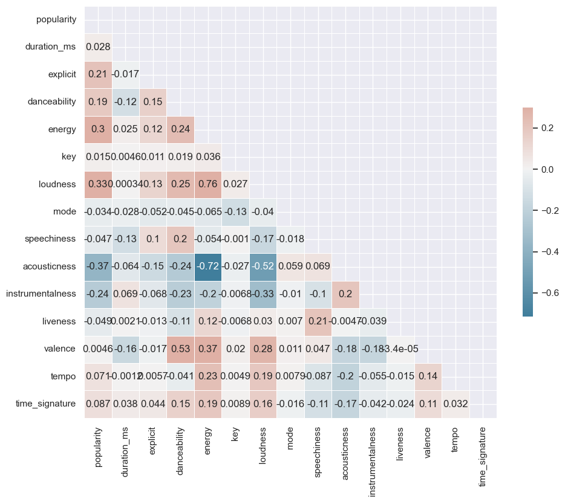

```python
corr_1 = df_tracks.corr(method='pearson',numeric_only=True)

mask = np.triu(np.ones_like(corr_1, dtype=bool))
f, ax = plt.subplots(figsize=(11, 9))
cmap = sns.diverging_palette(230, 20, as_cmap=True)

sns.heatmap(corr_1, mask=mask, cmap=cmap, vmax=.3, center=0,
            square=True, linewidths=.5, cbar_kws={"shrink": .5}, annot=True)
plt.show()
```

From the heatmap, we can discern that most variables do not exhibit strong correlations with each other. Importantly, none of the values showcase a high correlation with popularity. The features most positively correlated with popularity are loudness and energy, with both having nearly identical correlation values. On the other end, acousticness is the most negatively correlated feature, followed closely by instrumentalness. Among all the features, energy and loudness are the most closely related, which makes sense as loudness often corresponds with a song’s energy. Based on these observations, we can delve deeper into the relationship between popularity, energy, and loudness. Additionally, both danceability and loudness have a positive correlation with a song’s valence.

```python
df_tracks['release_date'] = pd.to_datetime(df_tracks['release_date'], errors='coerce')
```

```python
df_2010 = df_tracks[df_tracks['release_date'].dt.year >= 2010]
```

```python
df_2010['type'] = 'Others'
```

```python
df_energy = df_2010[['energy', 'type']]
df_energy_popular = df_spotify_history[['energy']].copy()
df_energy_popular['energy'] = df_energy_popular['energy'] / 100
df_energy_popular['type'] = 'Popular'
```

```python
df_compare_energy = pd.concat([df_energy, df_energy_popular], axis=0)
```

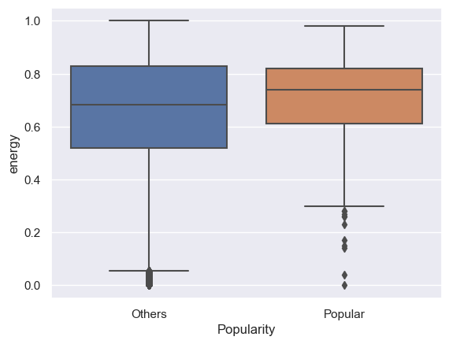

```python
sns.boxplot(x="type", y='energy', data=df_compare_energy)
plt.xlabel('Popularity')
plt.show()
```

This plot contrasts the energy distribution of top songs with that of all songs since 2010. Notably, the median energy of top songs is consistently higher than that of all songs. Furthermore, the energy of top songs tends to cluster within the 0.6-0.8 range, whereas the energy distribution for all songs is more dispersed.

```python
df_tracks['year'] = df_tracks['release_date'].dt.year
df_spotify_history['energy'] = df_spotify_history['energy'] / 100
```

```python
len(df_tracks[df_tracks['year'] == 2010])
```

```
8761
```

```python
len(df_spotify_history[df_spotify_history['year'] == 2010])
```

```
51
```

```python
# Bootstrap sampling the enegry column for each year beacuse lack of data

bootstrap_samples = {'energy': [], 'year': []}

for year, group in df_spotify_history.groupby('year'):
    for _ in range(100):  # bootstrap 100 times for each year
        sample = group['energy'].sample(len(group), replace=True).tolist()
        bootstrap_samples['year'] = bootstrap_samples['year'] + [year] * len(sample)
        bootstrap_samples['energy'] = bootstrap_samples['energy'] + sample
```

```python
df_bootstrap = pd.DataFrame(bootstrap_samples)
```

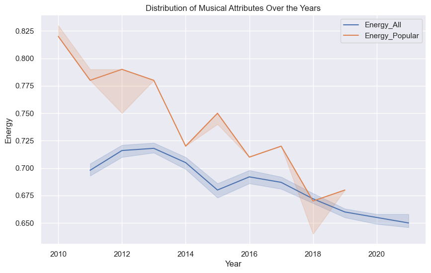

```python
sns.set_theme()

# Create line plots for each genre or attribute
plt.figure(figsize=(10, 6))
sns.lineplot(data=df_tracks[df_tracks['year'] > 2010], x='year', y='energy', label='Energy_All', estimator='median')
sns.lineplot(data=df_bootstrap, x='year', y='energy', label='Energy_Popular', estimator='median')

# sns.lineplot(data=df_spotify_history, x='year', y='loudness', label='Loudness of Popular Song', estimator='median')
# sns.lineplot(data=df_tracks[df_tracks['year'] > 2010], x='year', y='loudness', label='Loudness of All Song', estimator='median')

# ... Add other attributes as needed


# Add title, labels, and legend
plt.title('Distribution of Musical Attributes Over the Years')
plt.xlabel('Year')
plt.ylabel('Energy')
plt.legend()

# Show the plot
plt.show()
```

The plot illustrating the change in energy distribution of both top songs and other songs over the past decade offers intriguing insights. Notably, while the median energy value of top songs consistently surpasses that of all songs, this gap has been narrowing over time. Furthermore, there’s a discernible downward trend in song energy over the years. This could reflect a shift in musical preferences or a change in the characteristics of listeners.

### Music consumer traits

```python
# load the data
df_listener = pd.read_csv('../data/01-modified-data/last.fm.data/users_cleaned.csv')
```

```python
df_listener.head()
```

|  | user_id | country | age | gender | creation_time |
| --- | --- | --- | --- | --- | --- |
| 0 | 2 | UK | 30-35 | m | 2002-10-29 01:00:00 |
| 1 | 6 | AT | 25-30 | n | 2003-07-23 02:00:00 |
| 2 | 14 | UK | 45-50 | m | 2003-02-18 21:44:13 |
| 3 | 15 | US | 25-30 | m | 2003-02-24 03:30:33 |
| 4 | 20 | unknown | NaN | n | 2003-03-19 13:18:50 |

The dataset is mostly categroical data so there is no statistical summary for this dataset.

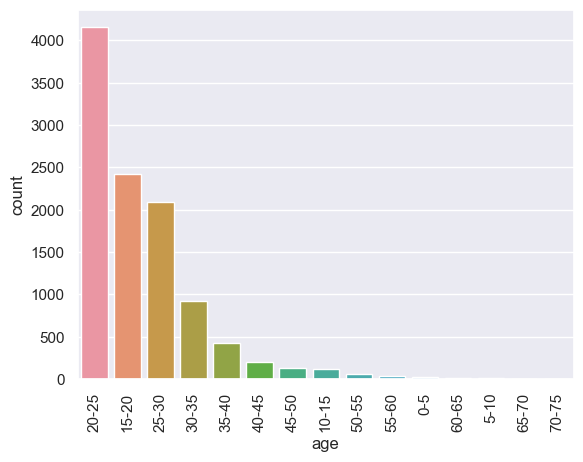

```python
order = df_listener['age'].value_counts().index
sns.countplot(x='age', data=df_listener, order=order)
plt.xticks(rotation=90)
plt.show()
```

We are particularly interested in the age demographics. This plot reveals that the 20-25 year age group boasts the highest number of streaming users. In fact, the majority of users fall between the ages of 15 and 35. This underscores the significant influence of teenagers and Gen Z on the current streaming market.

```python
# load the data
df_listen_event = pd.read_csv('../data/01-modified-data/last.fm.data/listening_events_sample.csv')
```

```python
# construc the dataset

df_listen_info = df_listen_event.merge(df_listener, how='left', left_on='user_id', right_on='user_id')
```

```python
# drop the missing value
df_listen_info.dropna(inplace=True)
```

```python
df_listen_info.head()
```

|  | user_id | track_id | album_id | timestamp | country | age | gender | creation_time |
| --- | --- | --- | --- | --- | --- | --- | --- | --- |
| 0 | 87459 | 21395420 | 17213208 | 2020-02-07 12:59:11 | ES | 15-20 | f | 2012-02-01 18:36:00 |
| 1 | 40265 | 27546101 | 20396068 | 2020-01-21 16:34:24 | US | 20-25 | f | 2009-11-15 12:17:35 |
| 2 | 29530 | 32308561 | 16367793 | 2020-02-07 12:37:20 | BR | 20-25 | m | 2009-01-24 01:42:53 |
| 3 | 111719 | 14820954 | 10307272 | 2020-03-07 05:32:22 | SE | 15-20 | m | 2012-05-02 23:13:26 |
| 4 | 33564 | 9337136 | 6639849 | 2020-01-08 10:11:02 | HR | 20-25 | m | 2009-05-03 12:32:00 |

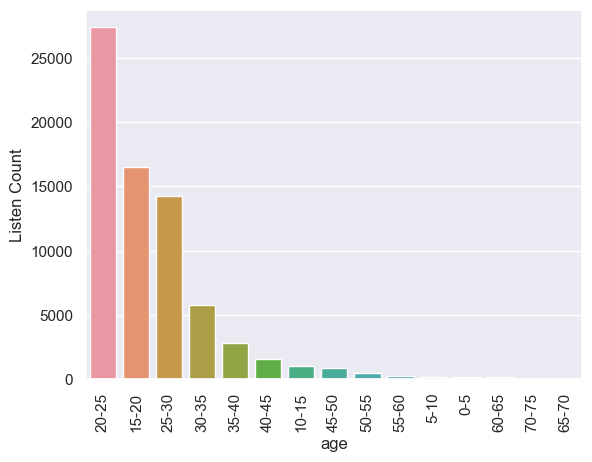

```python
order = df_listen_info['age'].value_counts().index
sns.countplot(x='age', data=df_listen_info, order=order)
plt.xticks(rotation=90)
plt.ylabel('Listen Count')
plt.show()
```

From this graph, we can determine which group of listeners contributes to the most listening events. Interestingly, the order aligns closely with the number of consumers in each group.

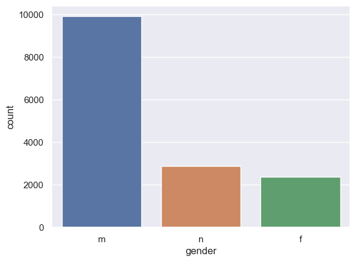

```python
sns.countplot(x='gender', data=df_listener)
```

From this plot, it appears that males are the predominant users of the streaming service. This is somewhat surprising, as one might expect a more balanced number of male and female listeners. While there is a segment of users who do not disclose their gender, it doesn’t offset the noticeable gender imbalance.

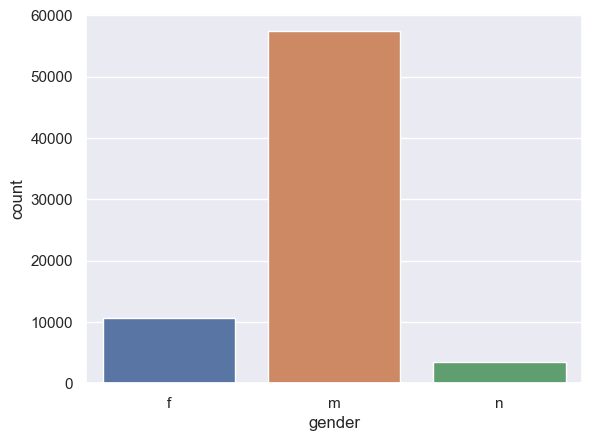

```python
sns.countplot(x='gender', data=df_listen_info)
```

From the plot, it’s evident that males account for the majority of the listening events. This suggests that males are more inclined to listen to music frequently, as their representation in listening events is disproportionately higher than their actual numbers compared to females. Interestingly, individuals who choose not to disclose their gender appear to listen less frequently. Despite having a larger listener count, the number of listening events associated with this group is lower than that of females.

[output not shown]

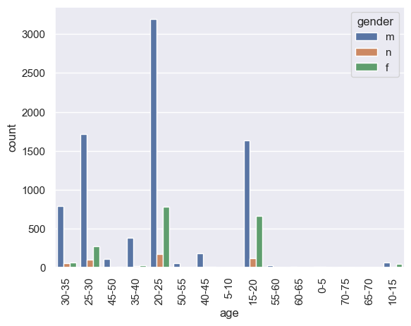

```python
sns.countplot(x='age', data=df_listener, hue='gender')
plt.xticks(rotation=90)
```

From the plot, it’s evident that males dominate the listener count across all age groups. Notably, the number of listeners who choose not to disclose their gender is increasingly prevalent among the 15-25 age group.

```python
# read the data
df_music = pd.read_csv('../data/01-modified-data/last.fm.data/tracks_cleaned.csv')
```

```python
# merge the data
df_listen_info_music = df_listen_info.merge(df_music, how='left', left_on='track_id', right_on='track_id')
```

```python
df_listen_info_music.head()
```

|  | user_id | track_id | album_id | timestamp | country | age | gender | creation_time | artist | track |
| --- | --- | --- | --- | --- | --- | --- | --- | --- | --- | --- |
| 0 | 52710 | 9299950 | 16682758 | 2020-02-14 09:52:25 | LT | NaN | f | 2010-08-18 19:52:37 | EERA | Christine |
| 1 | 4462 | 41878638 | 10034639 | 2020-01-10 04:40:28 | CL | 25-30 | m | 2006-03-21 17:47:37 | Little Mix | Touch |
| 2 | 43790 | 38231384 | 9469808 | 2020-02-26 22:33:45 | IT | 15-20 | m | 2010-01-07 21:10:59 | Broken Social Scene | Sweetest Kill |
| 3 | 62831 | 18075725 | 20196159 | 2020-03-04 09:57:50 | ID | 15-20 | m | 2011-03-20 05:19:10 | Neck Deep | Heavy Lies |
| 4 | 22870 | 6576931 | 8946033 | 2020-03-10 23:50:23 | unknown | NaN | n | 2008-07-18 20:41:36 | Imagine Dragons | Believer |

```python
df_listen_info_music.groupby('age')['artist'].apply(lambda x: x.value_counts().idxmax())
```

```
age
0-5                               米津玄師
10-15                   Porcupine Tree
15-20           White Noise Baby Sleep
20-25                      Tame Impala
25-30                          Beyoncé
30-35                   Chris Kläfford
35-40    Pen of Chaos et le Naheulband
40-45                       • ukeboy •
45-50                   The Beach Boys
5-10                Alessandro Cortini
50-55                       Pink Floyd
55-60                      Count Basie
60-65                              ДДТ
65-70                      Ocean Grove
70-75                          Sirenia
Name: artist, dtype: object
```

```python
df_listen_info_music.groupby('age')['artist'].value_counts()['15-20']
```

```
artist
White Noise Baby Sleep         206
Billie Eilish                   68
BTS                             59
Tame Impala                     55
Grimes                          49
                              ...
Godspeed You! Black Emperor      1
Godfather of Harlem              1
God Help the Girl                1
God Dethroned                    1
Go Radio                         1
Name: count, Length: 8445, dtype: int64
```

```python
df_listen_info_music.groupby('age')['artist'].value_counts()['20-25']
```

```
artist
Tame Impala      85
Rammstein        72
Die drei ???     60
Slipknot         60
Eminem           57
                 ..
Kumbia Queers     1
Kumbhaka          1
Kula Shaker       1
Kuedo             1
Kubichek!         1
Name: count, Length: 13149, dtype: int64
```

```python
df_listen_info_music.groupby('age')['artist'].value_counts()['25-30']
```

```
artist
Beyoncé          71
Helene Bøksle    56
Little Mix       50
Adam Sapphire    46
Die drei ???     41
                 ..
Age Of Echoes     1
Agaton Simon      1
Agathocles        1
Agar Agar         1
Afterbirth        1
Name: count, Length: 7922, dtype: int64
```

```python
# Read the data
df_sound_info = pd.read_csv('../data/01-modified-data/last.fm.data/last_fm_track_info.csv')
```

```python
# merge the dataset

df_listen_sound = df_listen_info.merge(df_sound_info, how='left', left_on='track_id', right_on='track_id')
```

```python
# Drop the missing value
df_listen_sound.dropna(inplace=True)
```

```python
df_listen_sound.head()
```

|  | user_id | track_id | album_id | timestamp | country | age | gender | creation_time | danceability | energy | key | loudness | mode | speechiness | acousticness | instrumentalness | liveness | valence | tempo | id |
| --- | --- | --- | --- | --- | --- | --- | --- | --- | --- | --- | --- | --- | --- | --- | --- | --- | --- | --- | --- | --- |
| 1 | 4462 | 41878638 | 10034639 | 2020-01-10 04:40:28 | CL | 25-30 | m | 2006-03-21 17:47:37 | 0.415 | 0.104 | 0.0 | -11.830 | 1.0 | 0.0426 | 0.955000 | 0.000004 | 0.1040 | 0.180 | 82.006 | 4g2WiijzSKzH8PApKDbadN |
| 2 | 43790 | 38231384 | 9469808 | 2020-02-26 22:33:45 | IT | 15-20 | m | 2010-01-07 21:10:59 | 0.708 | 0.384 | 5.0 | -12.427 | 1.0 | 0.0302 | 0.089300 | 0.841000 | 0.0961 | 0.691 | 87.961 | 488u1IbVEsaC7fxjABWjHx |
| 5 | 51493 | 43590126 | 444628 | 2020-01-23 10:15:28 | UK | 20-25 | m | 2010-07-21 11:40:40 | 0.486 | 0.617 | 5.0 | -7.115 | 0.0 | 0.0287 | 0.095400 | 0.000003 | 0.1090 | 0.417 | 138.015 | 1mea3bSkSGXuIRvnydlB5b |
| 13 | 2194 | 41200695 | 19859102 | 2020-03-09 19:06:27 | UK | 20-25 | m | 2005-08-22 06:45:25 | 0.566 | 0.869 | 2.0 | -6.084 | 1.0 | 0.1000 | 0.000916 | 0.003460 | 0.1140 | 0.647 | 178.113 | 3C84jaEdYxiq8LC4jwYqj6 |
| 21 | 659 | 6989555 | 5566359 | 2020-01-20 20:07:24 | DE | 20-25 | m | 2004-12-27 21:33:40 | 0.376 | 0.982 | 5.0 | -3.779 | 0.0 | 0.0625 | 0.000057 | 0.000005 | 0.1600 | 0.150 | 148.926 | 6REc2Tq4G2RW5zKXtusTLF |

```python
df_listen_sound = df_listen_sound[(df_listen_sound['age'] == '15-20') | (df_listen_sound['age'] == '20-25') | (df_listen_sound['age'] == '25-30')]
```

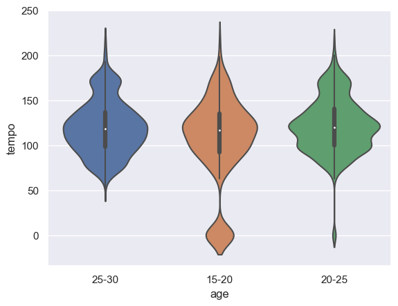

```python
sns.violinplot(data=df_listen_sound, x="age", y="tempo")
```

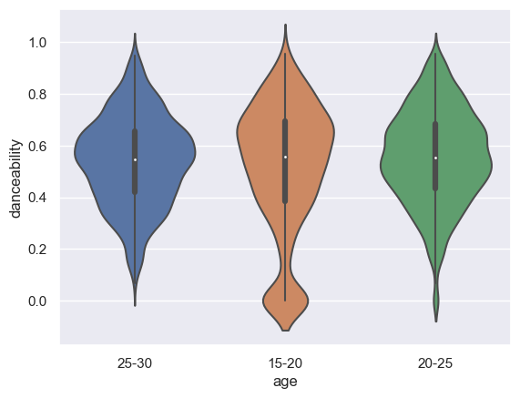

```python
sns.violinplot(data=df_listen_sound, x="age", y="danceability")
```

### Conclusion

In conclusion, in this EDA process, we can gain following insight:

#### Hypothesis and Research Quesions

Base on these conclusion from priliminary EDA, we can now refiend our hypothesis and research questions in the following way:

1. As the generation Z is becoming the main force of the music consumer, the music is becoming more diverse and less energetic while more danceable.
2. This could also lead to the decline of the popularity of pop music or other classic genres, instead, new genres which fuse those genres before are emerging and taking the market fast.
3. Gen Z will be more preferring to newer famous artists, and they are more open to music globalizaiton.
4. Platform like tik tok will be promoting more energetic and danceable songs in the future.
5. In the new generation, listeners could be clustered into more groups than before for haveing differnet music taste.

It is sure that more analysis need to be conduct after this EDA process.